# ACTIVIDAD 4 - UD4 PEDRO LLULL

## Apartado A

¿ Depende el coeficiente intelectual de medidas físicas ? Carga “ACTIVIDAD 4 UD4 iqphys.csv” y haz una regresión lineal múltiple:

```r
iqphys <- read.csv("iqphys.csv")
head(iqphys)
```

|  | PIQ | Brain | Height | Weight |
| --- | --- | --- | --- | --- |
| 1 | 124 | 81.69 | 64.5 | 118 |
| 2 | 150 | 103.84 | 73.3 | 143 |
| 3 | 128 | 96.54 | 68.8 | 172 |
| 4 | 134 | 95.15 | 65.0 | 147 |
| 5 | 110 | 92.88 | 69.0 | 146 |
| 6 | 131 | 99.13 | 64.5 | 138 |

```r
summary(iqphys)
```

```
      PIQ             Brain            Height          Weight
 Min.   : 72.00   Min.   : 79.06   Min.   :62.00   Min.   :106.0
 1st Qu.: 89.25   1st Qu.: 85.48   1st Qu.:66.00   1st Qu.:135.2
 Median :115.00   Median : 90.54   Median :68.00   Median :146.5
 Mean   :111.34   Mean   : 90.68   Mean   :68.42   Mean   :151.1
 3rd Qu.:128.00   3rd Qu.: 94.95   3rd Qu.:70.38   3rd Qu.:172.0
 Max.   :150.00   Max.   :107.95   Max.   :77.00   Max.   :192.0
```

```r
#No conozco bien la conversión al sistma americano
iqphys$Height_cm <- round(iqphys$Height * 2.54, 1)  # Convierte la altura a centímetros
iqphys$Weight_kg <- round(iqphys$Weight * 0.45359237, 1)  # Convierte el peso a kilogramos
head(iqphys)
```

|  | PIQ | Brain | Height | Weight | Height_cm | Weight_kg |
| --- | --- | --- | --- | --- | --- | --- |
| 1 | 124 | 81.69 | 64.5 | 118 | 163.8 | 53.5 |
| 2 | 150 | 103.84 | 73.3 | 143 | 186.2 | 64.9 |
| 3 | 128 | 96.54 | 68.8 | 172 | 174.8 | 78.0 |
| 4 | 134 | 95.15 | 65.0 | 147 | 165.1 | 66.7 |
| 5 | 110 | 92.88 | 69.0 | 146 | 175.3 | 66.2 |
| 6 | 131 | 99.13 | 64.5 | 138 | 163.8 | 62.6 |

```r
# Modelos de regresión lineal múltiple para sitema internacional y americano
modelo_iq_i <- lm(PIQ ~ Brain + Height_cm + Weight_kg, data = iqphys)
modelo_iq_a <- lm(PIQ ~ Brain + Height + Weight, data = iqphys)

# Resumen de los modelos
summary(modelo_iq_i)
```

```
Call:
lm(formula = PIQ ~ Brain + Height_cm + Weight_kg, data = iqphys)

Residuals:
   Min     1Q Median     3Q    Max
-32.74 -12.10  -3.84  14.26  51.69

Coefficients:
              Estimate Std. Error t value Pr(>|t|)
(Intercept)  1.108e+02  6.296e+01   1.760 0.087476 .
Brain        2.059e+00  5.638e-01   3.652 0.000866 ***
Height_cm   -1.071e+00  4.841e-01  -2.212 0.033768 *
Weight_kg   -5.244e-04  4.350e-01  -0.001 0.999045
---
Signif. codes:  0 ‘***’ 0.001 ‘**’ 0.01 ‘*’ 0.05 ‘.’ 0.1 ‘ ’ 1

Residual standard error: 19.8 on 34 degrees of freedom
Multiple R-squared:  0.2942,    Adjusted R-squared:  0.232
F-statistic: 4.725 on 3 and 34 DF,  p-value: 0.007333
```

```r
summary(modelo_iq_a)
```

```
Call:
lm(formula = PIQ ~ Brain + Height + Weight, data = iqphys)

Residuals:
   Min     1Q Median     3Q    Max
-32.74 -12.09  -3.84  14.17  51.69

Coefficients:
              Estimate Std. Error t value Pr(>|t|)
(Intercept)  1.114e+02  6.297e+01   1.768 0.085979 .
Brain        2.060e+00  5.634e-01   3.657 0.000856 ***
Height      -2.732e+00  1.229e+00  -2.222 0.033034 *
Weight       5.599e-04  1.971e-01   0.003 0.997750
---
Signif. codes:  0 ‘***’ 0.001 ‘**’ 0.01 ‘*’ 0.05 ‘.’ 0.1 ‘ ’ 1

Residual standard error: 19.79 on 34 degrees of freedom
Multiple R-squared:  0.2949,    Adjusted R-squared:  0.2327
F-statistic: 4.741 on 3 and 34 DF,  p-value: 0.007215
```

Asi pues:

- Coeficiente de “Brain” (tamaño del cerebro): 2.060 (positivo y significativo)
- Coeficiente de “Height” (altura en pulgadas): -2.732 (negativo y significativo)
- Coeficiente de “Weight” (peso en libras): 0.0005599 (no significativo)

El tamaño del cerebro tiene un efecto positivo y significativo en el PIQ después de tomar en cuenta la altura y el peso. Esto indica que el tamaño del cerebro sigue siendo relevante para el PIQ incluso después de considerar la altura y el peso.

- Da un intervalo de confianza para los coeficientes

```r
modelo_americano <- lm(PIQ ~ Brain + Height + Weight, data = iqphys)

# Obtiene intervalos de confianza para los coeficientes
intervalos_americanos <- confint(modelo_americano)
print(intervalos_americanos)
```

```
                  2.5 %      97.5 %
(Intercept) -16.6190567 239.3262733
Brain         0.9153051   3.2054285
Height       -5.2304287  -0.2334296
Weight       -0.3999266   0.4010465
```

Brain: El intervalo de confianza para el coeficiente de “Brain” va desde aproximadamente 0.92 hasta 3.21. Height (Altura en pulgadas): El intervalo de confianza va desde aproximadamente -5.23 a -0.23 para la variable “Height”. Weight (Peso en libras): El intervalo de confianza va desde aproximadamente -0.40 a 0.40 para la variable “Weight”. Si un intervalo no incluye el valor cero, el coeficiente se considera significativo. En este caso, los coeficientes de “Brain” e “Height” son significativos, mientras que el coeficiente de “Weight” incluye cero en su intervalo de confianza, lo que indica que no es significativo en este modelo.

- ¿ Cuál es el intervalo de confianza de IQ para los valores de los predictores: tamaño del cerebero = 95, altura = 70, peso = 180 ?

```r
# Valores de los predictores para calcular el IQ
tamaño_cerebro <- 95
altura <- 70
peso <- 180

# Crea un nuevo dataframe con estos valores
n_valores <- data.frame(Brain = tamaño_cerebro, Height = altura, Weight = peso)

# Utiliza la función predict para obtener el valor predicho de IQ
iq_predicho <- predict(modelo_americano, newdata = n_valores, interval = "confidence")

# Muestra el valor predicho de IQ y los límites del intervalo de confianza
print(iq_predicho)
```

```
       fit      lwr      upr
1 115.9542 104.5602 127.3482
```

El intervalo de confianza del (IQ) para los valores de los predictores (tamaño del cerebro = 95, altura = 70, peso = 180) utilizando el modelo americano es el siguiente:

Valor predicho de IQ (fit): 115.9542 Límite inferior del intervalo de confianza (lwr): 104.5602 Límite superior del intervalo de confianza (upr): 127.3482

Esto significa que, con un nivel de confianza del 95%, el valor predicho de IQ para un individuo con un tamaño de cerebro de 95, altura de 70 pulgadas y peso de 180 libras está en el rango de aproximadamente 104.56 a 127.35. El valor más probable de IQ es 115.95.

- Siguen los residuos una distribución normal? Haz las representaciones del histograma y de de la gráfica cuantil-cuantil convenientes.

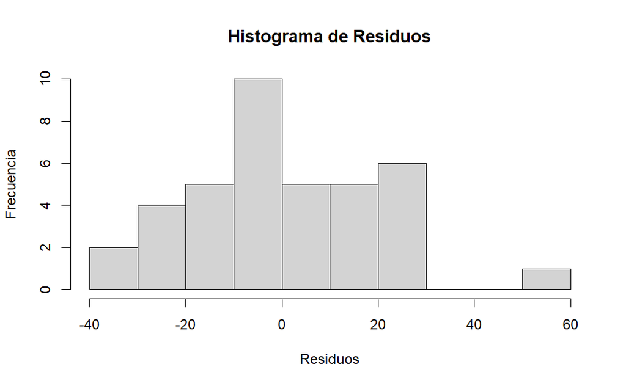

```r
# Residuos del modelo
residuos <- resid(modelo_americano)

# Histograma de los residuos
hist(residuos, main = "Histograma de Residuos", xlab = "Residuos", ylab = "Frecuencia")
```

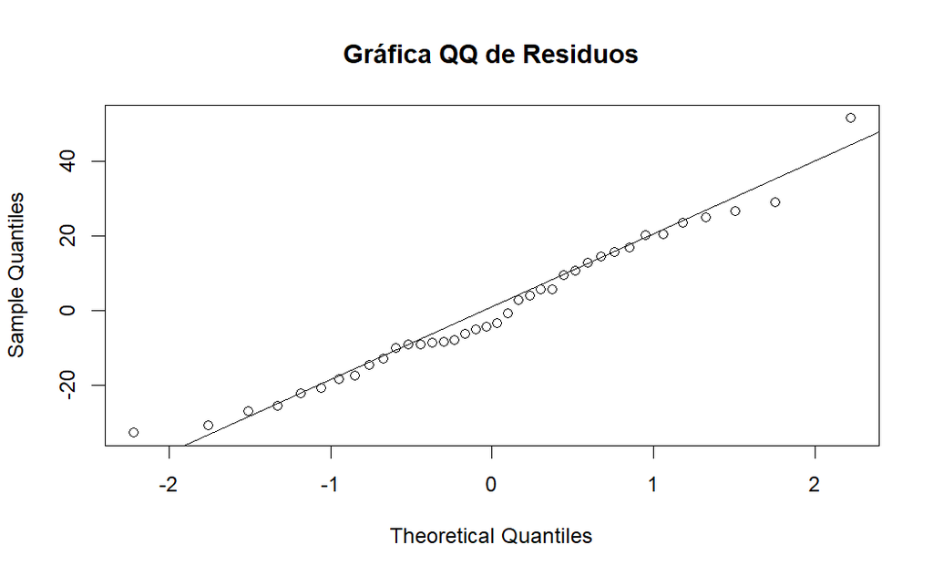

```r
# Gráfica cuantil-cuantil (Q-Q plot) de los residuos
qqnorm(residuos, main = "Gráfica QQ de Residuos")
qqline(residuos)
```

## Apartado B

- Carga el dataset `prostate.csv`

```r
prostate <- read.csv("prostate.csv")
head(prostate)
```

|  | lcavol | lweight | age | lbph | svi | lcp | gleason | pgg45 | lpsa | train |
| --- | --- | --- | --- | --- | --- | --- | --- | --- | --- | --- |
| 1 | -0.5798185 | 2.769459 | 50 | -1.386294 | 0 | -1.386294 | 6 | 0 | -0.4307829 | TRUE |
| 2 | -0.9942523 | 3.319626 | 58 | -1.386294 | 0 | -1.386294 | 6 | 0 | -0.1625189 | TRUE |
| 3 | -0.5108256 | 2.691243 | 74 | -1.386294 | 0 | -1.386294 | 7 | 20 | -0.1625189 | TRUE |
| 4 | -1.2039728 | 3.282789 | 58 | -1.386294 | 0 | -1.386294 | 6 | 0 | -0.1625189 | TRUE |
| 5 | 0.7514161 | 3.432373 | 62 | -1.386294 | 0 | -1.386294 | 6 | 0 | 0.3715636 | TRUE |
| 6 | -1.0498221 | 3.228826 | 50 | -1.386294 | 0 | -1.386294 | 6 | 0 | 0.7654678 | TRUE |

```r
summary(prostate)
```

```
     lcavol           lweight           age             lbph              svi              lcp
 Min.   :-1.3471   Min.   :2.375   Min.   :41.00   Min.   :-1.3863   Min.   :0.0000   Min.   :-1.3863
 1st Qu.: 0.5128   1st Qu.:3.376   1st Qu.:60.00   1st Qu.:-1.3863   1st Qu.:0.0000   1st Qu.:-1.3863
 Median : 1.4469   Median :3.623   Median :65.00   Median : 0.3001   Median :0.0000   Median :-0.7985
 Mean   : 1.3500   Mean   :3.629   Mean   :63.87   Mean   : 0.1004   Mean   :0.2165   Mean   :-0.1794
 3rd Qu.: 2.1270   3rd Qu.:3.876   3rd Qu.:68.00   3rd Qu.: 1.5581   3rd Qu.:0.0000   3rd Qu.: 1.1787
 Max.   : 3.8210   Max.   :4.780   Max.   :79.00   Max.   : 2.3263   Max.   :1.0000   Max.   : 2.9042
    gleason          pgg45             lpsa           train
 Min.   :6.000   Min.   :  0.00   Min.   :-0.4308   Mode :logical
 1st Qu.:6.000   1st Qu.:  0.00   1st Qu.: 1.7317   FALSE:30
 Median :7.000   Median : 15.00   Median : 2.5915   TRUE :67
 Mean   :6.753   Mean   : 24.38   Mean   : 2.4784
 3rd Qu.:7.000   3rd Qu.: 40.00   3rd Qu.: 3.0564
 Max.   :9.000   Max.   :100.00   Max.   : 5.5829
```

- Elimina la columna train

```r
prostate2 <- subset(prostate, select = -train)
head(prostate2)
```

|  | lcavol | lweight | age | lbph | svi | lcp | gleason | pgg45 | lpsa |
| --- | --- | --- | --- | --- | --- | --- | --- | --- | --- |
| 1 | -0.5798185 | 2.769459 | 50 | -1.386294 | 0 | -1.386294 | 6 | 0 | -0.4307829 |
| 2 | -0.9942523 | 3.319626 | 58 | -1.386294 | 0 | -1.386294 | 6 | 0 | -0.1625189 |
| 3 | -0.5108256 | 2.691243 | 74 | -1.386294 | 0 | -1.386294 | 7 | 20 | -0.1625189 |
| 4 | -1.2039728 | 3.282789 | 58 | -1.386294 | 0 | -1.386294 | 6 | 0 | -0.1625189 |
| 5 | 0.7514161 | 3.432373 | 62 | -1.386294 | 0 | -1.386294 | 6 | 0 | 0.3715636 |
| 6 | -1.0498221 | 3.228826 | 50 | -1.386294 | 0 | -1.386294 | 6 | 0 | 0.7654678 |

- ¿Cuál es el mejor modelo que explica la variable lpsa?

```r
#Preparamos el modelo teniendo en cuenta LPSA como dependiente

modl <- lm(lpsa~.,data=prostate2)
summary(modl)
```

```
Call:
lm(formula = lpsa ~ ., data = prostate2)

Residuals:
     Min       1Q   Median       3Q      Max
-1.76644 -0.35510 -0.00328  0.38087  1.55770

Coefficients:
             Estimate Std. Error t value Pr(>|t|)
(Intercept)  0.181561   1.320568   0.137  0.89096
lcavol       0.564341   0.087833   6.425 6.55e-09 ***
lweight      0.622020   0.200897   3.096  0.00263 **
age         -0.021248   0.011084  -1.917  0.05848 .
lbph         0.096713   0.057913   1.670  0.09848 .
svi          0.761673   0.241176   3.158  0.00218 **
lcp         -0.106051   0.089868  -1.180  0.24115
gleason      0.049228   0.155341   0.317  0.75207
pgg45        0.004458   0.004365   1.021  0.31000
---
Signif. codes:  0 ‘***’ 0.001 ‘**’ 0.01 ‘*’ 0.05 ‘.’ 0.1 ‘ ’ 1

Residual standard error: 0.6995 on 88 degrees of freedom
Multiple R-squared:  0.6634,    Adjusted R-squared:  0.6328
F-statistic: 21.68 on 8 and 88 DF,  p-value: < 2.2e-16
```

```r
confint(modl)
```

```
                   2.5 %       97.5 %
(Intercept) -2.442790925 2.8059126487
lcavol       0.389790747 0.7388918112
lweight      0.222779918 1.0212596550
age         -0.043275472 0.0007791021
lbph        -0.018376765 0.2118018106
svi          0.282387398 1.2409594092
lcp         -0.284644617 0.0725427394
gleason     -0.259479005 0.3579348707
pgg45       -0.004217659 0.0131326824
```

```r
M <- cor(prostate2)
M[9,]
```

```
   lcavol   lweight       age      lbph       svi       lcp   gleason     pgg45      lpsa
0.7344603 0.4333194 0.1695928 0.1798094 0.5662182 0.5488132 0.3689868 0.4223159 1.0000000
```

Vemos que la distribución de los residuos es “normal” ya que, una mediana cercana a cero y el hecho de que el tercer cuartil sea positivo sugieren que el modelo generalmente predice bien. Las independientes LCAVOL LWEIGHT y SVI son buenas candidatas para probar un modelo. El R-cuadrado ajustado es de 0.6328, un valor alto. Esto significa que, en nuestro modelo, aproximadamente el 63.28% de la variabilidad en la variable dependiente (lo que estamos tratando de predecir) se explica teniendo en cuenta las variables independientes. En la medida de los intervalos de confianza hay que tener en cuente que si un intervalo incluye el valor cero, eso podría indicar que el coeficiente correspondiente no es estadísticamente significativo en la predicción de la variable dependiente. Por otro lado, si el intervalo no incluye el valor cero, el coeficiente se considera estadísticamente significativo.

```r
# Sacamos los valores AIC y BIC de los modelos entero y sin las variables que CREO, no aportan.
AIC(lm(lpsa~.,data=prostate2))
```

```
[1] 216.4952
```

```r
AIC(lm(lpsa~.-age-lbph-lcp-gleason-pgg45,data=prostate2))
```

```
[1] 214.0966
```

```r
BIC(lm(lpsa~.,data=prostate2))
```

```
[1] 242.2423
```

```r
BIC(lm(lpsa~.-age-lbph-lcp-gleason-pgg45,data=prostate2))
```

```
[1] 226.9702
```

```r
# Preparamos para comprobar el modelo paso a paso hacia adelante
library(MASS)
step_f <- stepAIC(lm(lpsa~1,data=prostate2), scope = lpsa~lcavol+lweight+age+lbph+svi+lcp+gleason+pgg45, direction = "forward")
```

```
Start:  AIC=28.84
lpsa ~ 1

          Df Sum of Sq     RSS     AIC
+ lcavol   1    69.003  58.915 -44.366
+ svi      1    41.011  86.907  -6.658
+ lcp      1    38.528  89.389  -3.926
+ lweight  1    24.019 103.899  10.665
+ pgg45    1    22.814 105.103  11.783
+ gleason  1    17.416 110.502  16.641
+ lbph     1     4.136 123.782  27.650
+ age      1     3.679 124.239  28.007
<none>                 127.918  28.838

Step:  AIC=-44.37
lpsa ~ lcavol

          Df Sum of Sq    RSS     AIC
+ lweight  1    7.1726 51.742 -54.958
+ svi      1    5.2375 53.677 -51.397
+ lbph     1    3.2658 55.649 -47.898
+ pgg45    1    1.6980 57.217 -45.203
<none>                 58.915 -44.366
+ lcp      1    0.6562 58.259 -43.452
+ gleason  1    0.4156 58.499 -43.053
+ age      1    0.0025 58.912 -42.370

Step:  AIC=-54.96
lpsa ~ lcavol + lweight

          Df Sum of Sq    RSS     AIC
+ svi      1    5.1737 46.568 -63.177
+ pgg45    1    1.8158 49.926 -56.424
<none>                 51.742 -54.958
+ lcp      1    0.8187 50.923 -54.506
+ gleason  1    0.7163 51.026 -54.311
+ age      1    0.6456 51.097 -54.176
+ lbph     1    0.4440 51.298 -53.794

Step:  AIC=-63.18
```

[output cut: 13 more lines]

```
          Df Sum of Sq    RSS     AIC
+ age      1   1.15879 44.437 -63.723
<none>                 45.595 -63.226
+ pgg45    1   0.33173 45.264 -61.934
+ gleason  1   0.20691 45.389 -61.667
+ lcp      1   0.10115 45.494 -61.441

Step:  AIC=-63.72
lpsa ~ lcavol + lweight + svi + lbph + age

          Df Sum of Sq    RSS     AIC
<none>                 44.437 -63.723
+ pgg45    1   0.66071 43.776 -63.176
+ gleason  1   0.47674 43.960 -62.769
+ lcp      1   0.13040 44.306 -62.008
```

```r
step_f
```

```
Call:
lm(formula = lpsa ~ lcavol + lweight + svi + lbph + age, data = prostate2)

Coefficients:
(Intercept)       lcavol      lweight          svi         lbph          age
    0.49473      0.54400      0.58821      0.71490      0.10122     -0.01644
```

```r
# Preparamos el modelo para ver las posibilidades paso a paso hacia atrás
mdl0 <- lm(lpsa~1,data=prostate2)
mdl1 <- lm(lpsa~lcavol+lweight+age+lbph+svi+lcp+gleason+pgg45,data=prostate2)

stepAIC(mdl1, direction = "backward")
```

```
Start:  AIC=-60.78
lpsa ~ lcavol + lweight + age + lbph + svi + lcp + gleason +
    pgg45

          Df Sum of Sq    RSS     AIC
- gleason  1    0.0491 43.108 -62.668
- pgg45    1    0.5102 43.569 -61.636
- lcp      1    0.6814 43.740 -61.256
<none>                 43.058 -60.779
- lbph     1    1.3646 44.423 -59.753
- age      1    1.7981 44.857 -58.810
- lweight  1    4.6907 47.749 -52.749
- svi      1    4.8803 47.939 -52.364
- lcavol   1   20.1994 63.258 -25.467

Step:  AIC=-62.67
lpsa ~ lcavol + lweight + age + lbph + svi + lcp + pgg45

          Df Sum of Sq    RSS     AIC
- lcp      1    0.6684 43.776 -63.176
<none>                 43.108 -62.668
- pgg45    1    1.1987 44.306 -62.008
- lbph     1    1.3844 44.492 -61.602
- age      1    1.7579 44.865 -60.791
- lweight  1    4.6429 47.751 -54.746
- svi      1    4.8333 47.941 -54.360
- lcavol   1   21.3191 64.427 -25.691

Step:  AIC=-63.18
lpsa ~ lcavol + lweight + age + lbph + svi + pgg45

          Df Sum of Sq    RSS     AIC
- pgg45    1    0.6607 44.437 -63.723
<none>                 43.776 -63.176
- lbph     1    1.3329 45.109 -62.266
- age      1    1.4878 45.264 -61.934
- svi      1    4.1766 47.953 -56.336
- lweight  1    4.6553 48.431 -55.373
- lcavol   1   22.7555 66.531 -24.572

Step:  AIC=-63.72
lpsa ~ lcavol + lweight + age + lbph + svi

          Df Sum of Sq    RSS     AIC
<none>                 44.437 -63.723
- age      1    1.1588 45.595 -63.226
- lbph     1    1.5087 45.945 -62.484
- lweight  1    4.3140 48.751 -56.735
- svi      1    5.8509 50.288 -53.724
- lcavol   1   25.9427 70.379 -21.119

Call:
lm(formula = lpsa ~ lcavol + lweight + age + lbph + svi, data = prostate2)

Coefficients:
(Intercept)       lcavol      lweight          age         lbph          svi
    0.49473      0.54400      0.58821     -0.01644      0.10122      0.71490
```

```r
# Preparamos para comprobar el modelo paso a paso en ambas direcciones
stepAIC(mdl0, direction = "both", scope=list(upper=mdl1,lower=mdl0))
```

```
Start:  AIC=28.84
lpsa ~ 1

          Df Sum of Sq     RSS     AIC
+ lcavol   1    69.003  58.915 -44.366
+ svi      1    41.011  86.907  -6.658
+ lcp      1    38.528  89.389  -3.926
+ lweight  1    24.019 103.899  10.665
+ pgg45    1    22.814 105.103  11.783
+ gleason  1    17.416 110.502  16.641
+ lbph     1     4.136 123.782  27.650
+ age      1     3.679 124.239  28.007
<none>                 127.918  28.838

Step:  AIC=-44.37
lpsa ~ lcavol

          Df Sum of Sq     RSS     AIC
+ lweight  1     7.173  51.742 -54.958
+ svi      1     5.237  53.677 -51.397
+ lbph     1     3.266  55.649 -47.898
+ pgg45    1     1.698  57.217 -45.203
<none>                  58.915 -44.366
+ lcp      1     0.656  58.259 -43.452
+ gleason  1     0.416  58.499 -43.053
+ age      1     0.003  58.912 -42.370
- lcavol   1    69.003 127.918  28.838

Step:  AIC=-54.96
lpsa ~ lcavol + lweight

          Df Sum of Sq     RSS     AIC
+ svi      1     5.174  46.568 -63.177
+ pgg45    1     1.816  49.926 -56.424
<none>                  51.742 -54.958
+ lcp      1     0.819  50.923 -54.506
+ gleason  1     0.716  51.026 -54.311
+ age      1     0.646  51.097 -54.176
+ lbph     1     0.444  51.298 -53.794
- lweight  1     7.173  58.915 -44.366
```

[output cut: 35 more lines]

```
- age      1    1.1588 45.595 -63.226
+ pgg45    1    0.6607 43.776 -63.176
+ gleason  1    0.4767 43.960 -62.769
- lbph     1    1.5087 45.945 -62.484
+ lcp      1    0.1304 44.306 -62.008
- lweight  1    4.3140 48.751 -56.735
- svi      1    5.8509 50.288 -53.724
- lcavol   1   25.9427 70.379 -21.119

Call:
lm(formula = lpsa ~ lcavol + lweight + svi + lbph + age, data = prostate2)

Coefficients:
(Intercept)       lcavol      lweight          svi         lbph          age
    0.49473      0.54400      0.58821      0.71490      0.10122     -0.01644
```

Con un -63.72, las 3 pruebas dan al modelo lm(formula = lpsa ~ lcavol + lweight + svi + lbph + age, data = prostate2) como el mejor

```r
# Vemos los datos de este modelo que nos ofrece el AIC
mdl3 <- lm(lpsa~lcavol+lweight+svi+lbph+age,data=prostate2)
extractAIC(mdl3,scale=0)
```

```
[1]   6.00000 -63.72263
```

```r
coefficients(mdl3)
```

```
(Intercept)      lcavol     lweight         svi        lbph         age
 0.49472926  0.54399786  0.58821270  0.71490398  0.10122333 -0.01644485
```

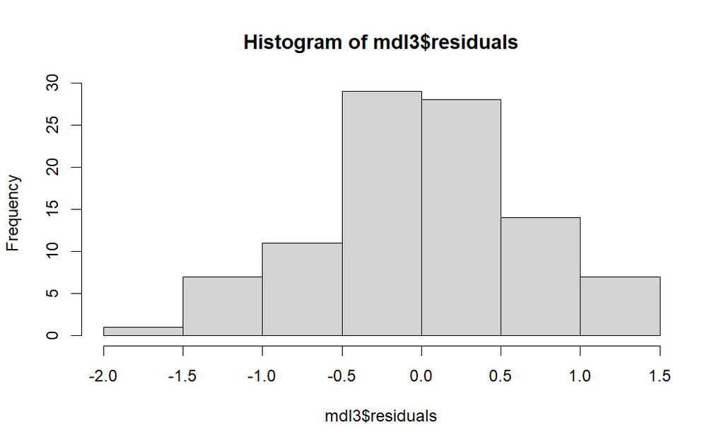

```r
hist(mdl3$residuals)
```

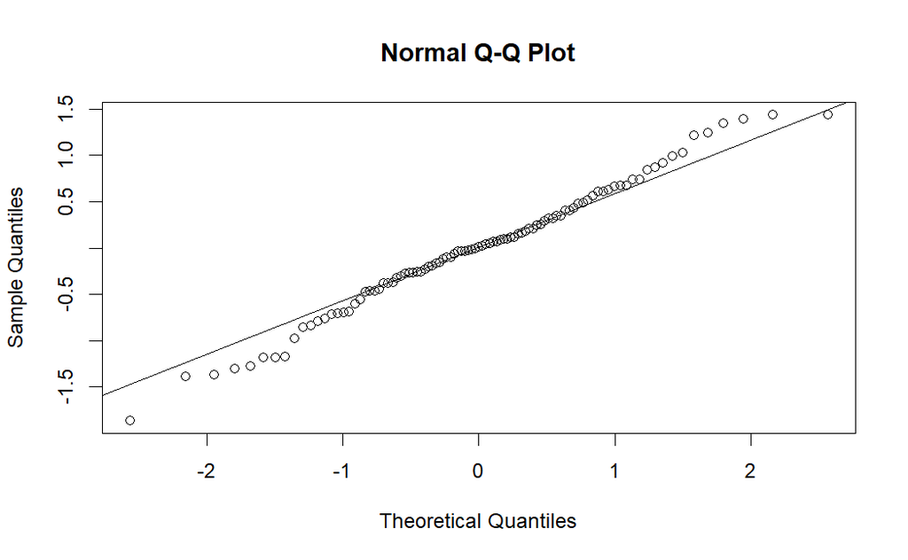

```r
qqnorm(mdl3$residuals)
qqline(mdl3$residuals)
```

```r
shapiro.test(mdl3$residuals)
```

```
    Shapiro-Wilk normality test

data:  mdl3$residuals
W = 0.9886, p-value = 0.5753
```

```r
summary(mdl3)
```

```
Call:
lm(formula = lpsa ~ lcavol + lweight + svi + lbph + age, data = prostate2)

Residuals:
     Min       1Q   Median       3Q      Max
-1.86717 -0.37725  0.01257  0.40252  1.44544

Coefficients:
            Estimate Std. Error t value Pr(>|t|)
(Intercept)  0.49473    0.87652   0.564  0.57385
lcavol       0.54400    0.07463   7.289 1.11e-10 ***
lweight      0.58821    0.19790   2.972  0.00378 **
svi          0.71490    0.20653   3.461  0.00082 ***
lbph         0.10122    0.05759   1.758  0.08215 .
age         -0.01644    0.01068  -1.540  0.12692
---
Signif. codes:  0 ‘***’ 0.001 ‘**’ 0.01 ‘*’ 0.05 ‘.’ 0.1 ‘ ’ 1

Residual standard error: 0.6988 on 91 degrees of freedom
Multiple R-squared:  0.6526,    Adjusted R-squared:  0.6335
F-statistic: 34.19 on 5 and 91 DF,  p-value: < 2.2e-16
```

Podemos ver que los residuos sesgan un poco hacia la izquierda, aunque la distribución es bastante normal. De las variables predictoras, vemos que LBPH y AGE no parecen tener una significancia para el modelo, aunque el AIC nos diga lo contrario

```r
# Vemos los datos de este modelo quitando LBPH y AGE que no añadian "aparentemente" valor al modelo
mdl3 <- lm(lpsa~lcavol+lweight+svi,data=prostate2)
extractAIC(mdl3,scale=0)
```

```
[1]   4.00000 -63.17744
```

```r
coefficients(mdl3)
```

```
(Intercept)      lcavol     lweight         svi
 -0.7771566   0.5258519   0.6617699   0.6656666
```

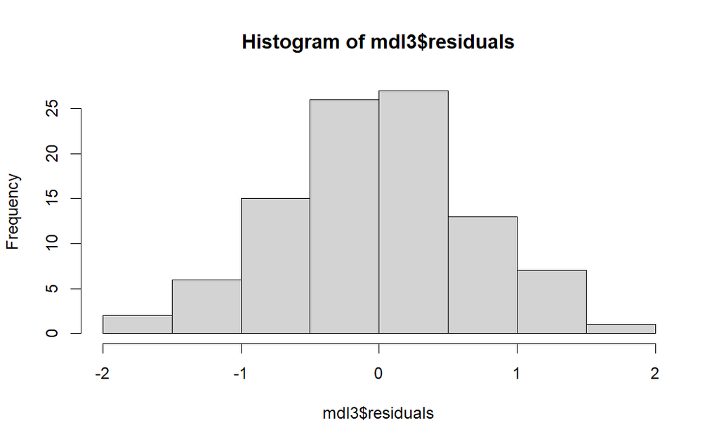

```r
hist(mdl3$residuals)
```

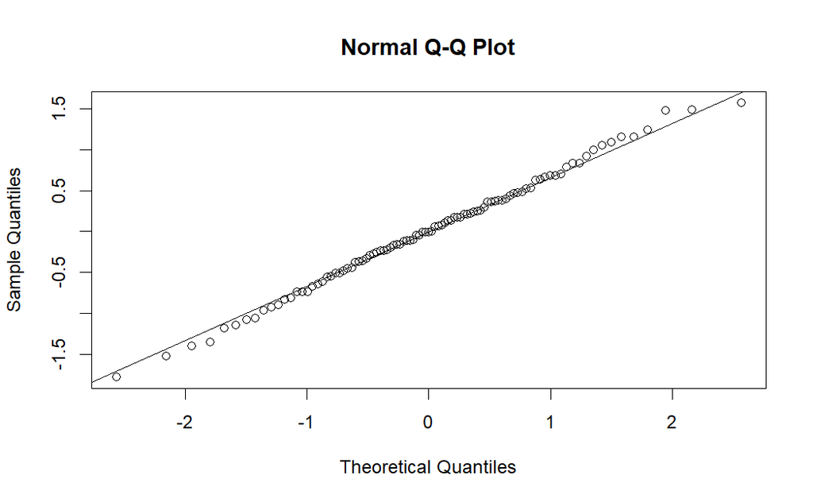

```r
qqnorm(mdl3$residuals)
qqline(mdl3$residuals)
```

```r
shapiro.test(mdl3$residuals)
```

```
    Shapiro-Wilk normality test

data:  mdl3$residuals
W = 0.99536, p-value = 0.9854
```

```r
summary(mdl3)
```

```
Call:
lm(formula = lpsa ~ lcavol + lweight + svi, data = prostate2)

Residuals:
     Min       1Q   Median       3Q      Max
-1.77745 -0.45004 -0.00254  0.44305  1.57574

Coefficients:
            Estimate Std. Error t value Pr(>|t|)
(Intercept) -0.77716    0.62300  -1.247 0.215367
lcavol       0.52585    0.07486   7.024 3.49e-10 ***
lweight      0.66177    0.17564   3.768 0.000289 ***
svi          0.66567    0.20709   3.214 0.001798 **
---
Signif. codes:  0 ‘***’ 0.001 ‘**’ 0.01 ‘*’ 0.05 ‘.’ 0.1 ‘ ’ 1

Residual standard error: 0.7076 on 93 degrees of freedom
Multiple R-squared:  0.6359,    Adjusted R-squared:  0.6242
F-statistic: 54.15 on 3 and 93 DF,  p-value: < 2.2e-16
```

Parece que aunque el AIC nos diga que el modelo con LBPH y AGE es “mejor”, si los quitamos del modelo los resultados son mejores. La distribucuón es mas próxima a una normal que con el modelo anterior, por lo que si tuvieramos que elegir entre el modelo propuesto por AIC o el ajustado según los datos del summary, nos quedaríamos con este último. Recordar que el AIC, BIC son técnicas, como otras, que nos ayudan a buscar el mejor modelo, pero es una ayuda, no la confirmación. Es mejor asegurar el modelo en base a esta y otras pruebas para así comparar resultados y métricas.

```r
extractAIC(lm(lpsa~lcavol+lweight+svi+lbph+age,data=prostate2),scale=0)
```

```
[1]   6.00000 -63.72263
```

```r
extractAIC(lm(lpsa~lcavol+lweight+svi,data=prostate2),scale=0)
```

```
[1]   4.00000 -63.17744
```

Si con los datos del summary anterior, descartamos LBPH y AGE (que aparentemente no añaden valor) y vemos que empeora el AIC, por lo que dejamos el modelo completo de 6 variables como el mejor de entre los dos según AIC.

Observamos pues que el AIC nos arroja que el mejor modelo es el que añade LBHP y AGE pero, si no añadimos estas variables al modelo, el resultado parece establecer un modelo más normalizado, o sea, MEJOR.

- Da un intervalo de confianza para los coeficientes

```r
confint(mdl3)
```

```
                 2.5 %    97.5 %
(Intercept) -2.0143101 0.4599968
lcavol       0.3771883 0.6745154
lweight      0.3129933 1.0105465
svi          0.2544272 1.0769060
```